## Overview

Concordance analysis allows us group strains by isotype. The following table summarizes the previous number of strains and isotypes, and the number of newly added strains and isotypes for this release.

[output not shown]

## Concordance score distribution and cutoff

We examined the pairwise concordance scores of all strains. Concordance values for every pair of strains was calculated as the number of shared genotypes divided by the total number of variants identified in each pair. If the concordance score was more than 0.9995, the strain pair is considered to belong to the same isotype.

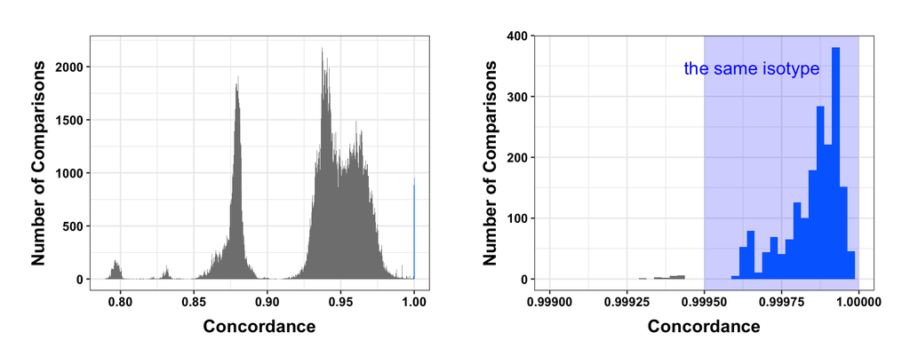

## Search for concordance for strain pairs

Strain comparisons are listed in the table below. Only concordance scores > 0.999 are shown.

| Strain | Strain | Total variants | Diff variants | Concordance | Is isotype |
| --- | --- | --- | --- | --- | --- |
| BRC20113 | BRC20067 | 3015175 | 172 | 0.999942955218188 | True |
| ECA1071 | ECA1070 | 3034039 | 238 | 0.999921556710379 | True |
| ECA1072 | ECA1070 | 3011057 | 223 | 0.999925939628509 | True |
| ECA1072 | ECA1071 | 3054374 | 257 | 0.999915858372288 | True |
| ECA1073 | ECA1070 | 3024512 | 192 | 0.999936518684667 | True |
| ECA1073 | ECA1071 | 3068368 | 232 | 0.999924389773326 | True |
| ECA1073 | ECA1072 | 3045340 | 197 | 0.999935310999757 | True |
| ECA1074 | ECA1070 | 3034588 | 244 | 0.999919593697728 | True |
| ECA1074 | ECA1071 | 3081103 | 209 | 0.999932167149232 | True |
| ECA1074 | ECA1072 | 3054260 | 235 | 0.999923058285804 | True |

[output cut: 1865 more lines]

## Changes from previous release

- Strain JU1511 was re-assigned to isotype JU792 from isotype JU1581. In the previous release (20180527), the JU1511 isotype grouping was based solely on RAD-seq data. We recently performed whole-genome sequencing of this strain, and on the basis of this have changed its isotype.

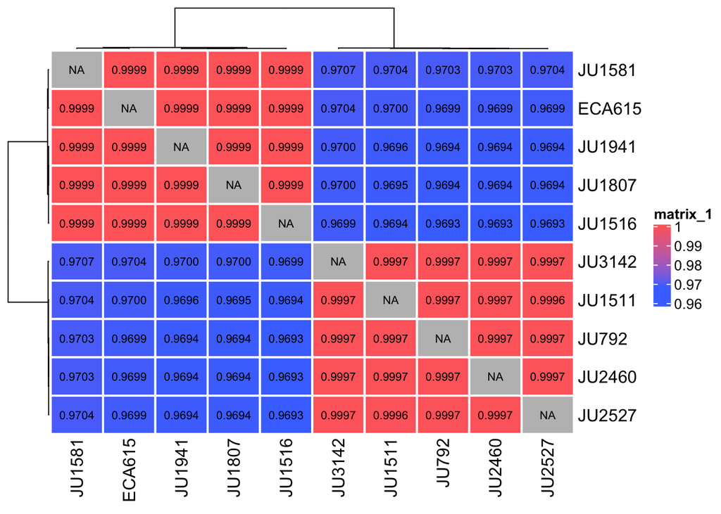

- Strain JU1580 was merged into isotype JU1793 since with current data and cutoffs, JU1580 is grouped with every strain of isotype JU1793.

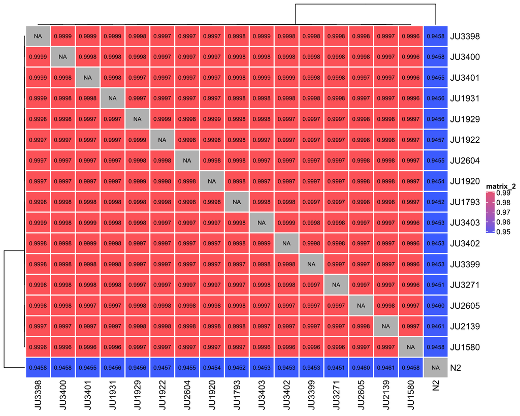